# EVS 2017 Data Review

Chris Rice

2024-03-09

According to the [website](https://search.gesis.org/research_data/ZA7500#variables%7Cexploredata-ZA7500_Varv72%7C0%7Cvariable_order%7Casc): *The European Values Study is a large-scale, cross-national and longitudinal survey research program on how Europeans think about family, work, religion, politics, and society. Repeated every nine years in an increasing number of countries, the survey provides insights into the ideas, beliefs, preferences, attitudes, values, and opinions of citizens all over Europe.*

Beginning steps were to create an account with the aforementioned website in order to extract either the SPSS or STATA file. In this case, we downloaded the STATA file in order to create an EVS 2017 analysis. Specific variables of this project’s interest were as follows:

1. Respondent’s age (continuous)
2. Respondent’s country (categorical)
3. Respondent’s education (categorical)
4. Respondent’s sex (categorical)
5. Respondent’s opinion on if jobs are scarce should national citizens have priority over immigrants (categorical)
6. Respondent’s opinion on if a child suffers when the mother is working (categorical)

## Table 1 - Categorical Variable Descriptive Statistics

```r
load("C:/Users/ricecakes/Desktop/Git1/HW-2/Rcode/df1c.RData")

calculate_frequencies <- function(data, var_name) {
  data %>%
    count(!!sym(var_name), name = "Frequency") %>%
    mutate(Percentage = Frequency / sum(Frequency) * 100,
           Category = as.character(!!sym(var_name)),
           Variable = var_name) %>%
    select(Variable, Category, Frequency, Percentage)
}

load("C:/Users/ricecakes/Desktop/Git1/HW-2/Rcode/df1c.RData")
# List of categorical variables
categorical_vars <- c("country", "education", "child_suffers", "jobs_are_scarce")

# Calculate frequencies and percentages for each variable and bind rows together
load("C:/Users/ricecakes/Desktop/Git1/HW-2/Rcode/df1c.RData")
categorical_summary <- map_dfr(categorical_vars, ~calculate_frequencies(df1c, .x))

# Display the table
load("C:/Users/ricecakes/Desktop/Git1/HW-2/Rcode/df1c.RData")
knitr::kable(categorical_summary, format = "html", booktabs = TRUE) %>%
  kable_styling("striped", "hover", full_width = F) %>%
  column_spec(1, width = "1cm") %>%
  column_spec(2, width = "2cm")
```

| Variable | Category | Frequency | Percentage |
| --- | --- | --- | --- |
| country | Albania | 1435 | 2.4142804 |
| country | Armenia | 1500 | 2.5236381 |
| country | Austria | 1644 | 2.7659073 |
| country | Azerbaijan | 1800 | 3.0283657 |
| country | Belarus | 1548 | 2.6043945 |
| country | Bosnia and Herzegovina | 1724 | 2.9005014 |
| country | Bulgaria | 1558 | 2.6212187 |
| country | Croatia | 1487 | 2.5017665 |
| country | Czechia | 1811 | 3.0468724 |
| country | Denmark | 3362 | 5.6563141 |
| country | Estonia | 1304 | 2.1938827 |
| country | Finland | 1199 | 2.0172280 |
| country | France | 1870 | 3.1461355 |
| country | Georgia | 2194 | 3.6912413 |
| country | Germany | 2170 | 3.6508631 |
| country | Great Britain | 1788 | 3.0081766 |
| country | Hungary | 1514 | 2.5471920 |
| country | Iceland | 1624 | 2.7322588 |
| country | Italy | 2277 | 3.8308826 |
| country | Latvia | 1335 | 2.2460379 |
| country | Lithuania | 1448 | 2.4361520 |
| country | Montenegro | 1003 | 1.6874727 |
| country | Netherlands | 2404 | 4.0445506 |
| country | North Macedonia | 1117 | 1.8792692 |
| country | Norway | 1122 | 1.8876813 |
| country | Poland | 1352 | 2.2746391 |
| country | Portugal | 1215 | 2.0441468 |
| country | Romania | 1613 | 2.7137521 |
| country | Russia | 1825 | 3.0704263 |
| country | Serbia | 1499 | 2.5219557 |
| country | Spain | 1209 | 2.0340523 |
| country | Sweden | 1194 | 2.0088159 |
| country | Switzerland | 3174 | 5.3400182 |
| country | Ukraine | 1612 | 2.7120697 |
| country | NA | 2507 | 4.2178404 |
| education | Bachelor or equivalent | 6508 | 10.9492244 |
| education | Doctoral or equivalent | 555 | 0.9337461 |
| education | Less than primary | 510 | 0.8580369 |
| education | Lower secondary | 8588 | 14.4486692 |
| education | Master or equivalent | 8397 | 14.1273260 |
| education | Post-secondary non tertiary | 2705 | 4.5509607 |
| education | Primary | 3028 | 5.0943841 |
| education | Short-cycle tertiary | 4553 | 7.6600828 |
| education | Upper secondary | 24121 | 40.5817827 |
| education | dont know | 81 | 0.1362765 |
| education | no answer | 308 | 0.5181870 |
| education | other | 84 | 0.1413237 |
| child_suffers | agree | 16484 | 27.7331000 |
| child_suffers | agree strongly | 5556 | 9.3475554 |
| child_suffers | disagree | 25122 | 42.2658905 |
| child_suffers | disagree strongly | 10918 | 18.3687203 |
| child_suffers | dont know | 1158 | 1.9482486 |
| child_suffers | no answer | 200 | 0.3364851 |
| jobs_are_scarce | agree | 16691 | 28.0813621 |
| jobs_are_scarce | agree strongly | 20308 | 34.1666947 |
| jobs_are_scarce | disagree | 8263 | 13.9018810 |
| jobs_are_scarce | disagree strongly | 4309 | 7.2495710 |
| jobs_are_scarce | dont know | 622 | 1.0464686 |
| jobs_are_scarce | multiple answers Mail | 1 | 0.0016824 |
| jobs_are_scarce | neither agree nor disagree | 9062 | 15.2461388 |
| jobs_are_scarce | no answer | 182 | 0.3062014 |

## Table 2 - Continuous Variable Descriptive Statistics

```r
df1c <- df1c %>%
  mutate(age = ifelse(age >= 82, 82, age))


df1c <- df1c %>%
  mutate(age = as.numeric(age),  # Attempt to convert age to numeric
         age = ifelse(is.na(age), NA, age))  # Non-numeric become NA


df1c %>%
  summarise(
    Mean = mean(age, na.rm = TRUE),
    SD = sd(age, na.rm = TRUE),
    Min = min(age, na.rm = TRUE),
    `25% Quantile` = quantile(age, 0.25, na.rm = TRUE),
    Median = median(age, na.rm = TRUE),
    `75% Quantile` = quantile(age, 0.75, na.rm = TRUE),
    Max = max(age, na.rm = TRUE)
  ) %>%
  knitr::kable()
```

| Mean | SD | Min | 25% Quantile | Median | 75% Quantile | Max |
| --- | --- | --- | --- | --- | --- | --- |
| 49.78912 | 17.79272 | 18 | 35 | 50 | 64 | 82 |

### No NAs in “age” confirmed

```r
 unique(df1c$age)
```

```
##  [1] 69 55 70 42 23 22 21 20 37 31 65 63 18 68 38 27 62 64 49 28 59 26 34 58 78
## [26] 54 46 19 39 60 36 71 50 57 25 82 47 77 44 24 53 30 29 41 56 66 43 40 51 72
## [51] 32 75 33 35 45 48 73 76 67 74 61 80 81 52 79
```

## How the 2 Vars of interest change with age (jobs_are_scare/child_suffers)

### jobs_are_scarce with age

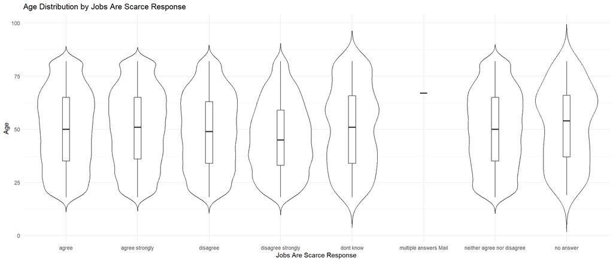

### child_suffers with age

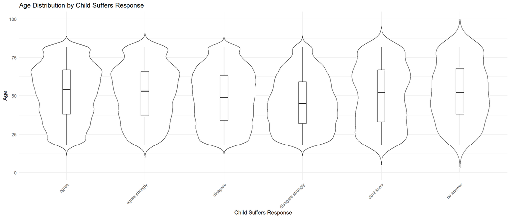

## Regression Models

```r
library(dplyr)
library(stargazer)
df1c <- df1c %>%
  mutate(age_squared = age^2,
         respondent_sex = as.factor(respondent_sex),
         education = as.factor(education))

model1 <- lm(jobs_are_scarce ~ age + age_squared + respondent_sex + education, data = df1c)
model2 <- lm(child_suffers ~ age + age_squared + respondent_sex + education, data = df1c)
stargazer(model1, model2, type = "text",
          title = "Regression Models Results",
          align = TRUE,
          header = FALSE,
          model.numbers = FALSE)
```

```
##
## Regression Models Results
## ==================================================================
##                                           Dependent variable:
##                                      -----------------------------
##                                      jobs_are_scarce child_suffers
## ------------------------------------------------------------------
## age                                      -0.004         -0.009
##
##
## age_squared                              0.00003        0.00003
##
##
## respondent_sexfemale                     -0.061          0.091
##
##
## respondent_sexmale                       -0.075          0.018
##
##
## respondent_sexno answer                   0.135          0.563
##
##
## educationDoctoral or equivalent           0.182          0.223
##
##
## educationdont know                        0.124         -0.101
##
##
## educationLess than primary               -0.452         -0.478
##
##
## educationLower secondary                 -0.465         -0.487
##
##
## educationMaster or equivalent            -0.175         -0.039
##
##
## educationno answer                        0.219         -0.075
##
##
## educationother                            0.691          0.320
##
##
## educationPost-secondary non tertiary     -0.408         -0.240
##
##
## educationPrimary                         -0.417         -0.489
##
##
## educationShort-cycle tertiary            -0.227         -0.143
##
##
## educationUpper secondary                 -0.489         -0.375
##
##
## Constant                                  3.361          3.169
##
##
## ------------------------------------------------------------------
## Observations                             59,438         59,438
## ==================================================================
## Note:                                  *p<0.1; **p<0.05; ***p<0.01
```